# Exploring the Titanic Dataset

Jayadeep

1 Nov 2017

# 1 Introduction

**Problem Description:** The sinking of the RMS Titanic is one of the most infamous shipwrecks in history. On April 15, 1912, during her maiden voyage, the Titanic sank after colliding with an iceberg, killing 1502 out of 2224 passengers and crew.

One of the reasons that the shipwreck led to such loss of life was that there were not enough lifeboats for the passengers and crew. Although there was some element of luck involved in surviving the sinking, some groups of people were more likely to survive than others, such as women, children, and the upper-class.

**Task:**

- Analyze what sorts of people were likely to survive
- Apply the tools of machine learning to predict which passengers survived the tragedy

Following are the main parts of our analysis:

- Missing value imputation
- Exploratory analysis and Feature engineering
- Prediction!

## 1.1 Load and check data

```r
# Load packages
library('ggplot2') # visualization
library('ggthemes') # visualization
library('scales') # visualization
library('dplyr') # data manipulation
library('caTools') # Spliting data
library('rms') # For step wise regression
```

Now that our packages are loaded, let’s read in and take a peek at the data.

```r
# Set Working Directory
setwd("C:/Users/sangi/Desktop/MUIT Course/")
# Read Data
dataset <- read.csv("train.csv",stringsAsFactors = F,na = "")
# First few entries of the data
head(dataset)
```

```
##   PassengerId Survived Pclass
## 1           1        0      3
## 2           2        1      1
## 3           3        1      3
## 4           4        1      1
## 5           5        0      3
## 6           6        0      3
##                                                  Name    Sex Age SibSp
## 1                             Braund, Mr. Owen Harris   male  22     1
## 2 Cumings, Mrs. John Bradley (Florence Briggs Thayer) female  38     1
## 3                              Heikkinen, Miss. Laina female  26     0
## 4        Futrelle, Mrs. Jacques Heath (Lily May Peel) female  35     1
## 5                            Allen, Mr. William Henry   male  35     0
## 6                                    Moran, Mr. James   male  NA     0
##   Parch           Ticket    Fare Cabin Embarked
## 1     0        A/5 21171  7.2500  <NA>        S
## 2     0         PC 17599 71.2833   C85        C
## 3     0 STON/O2. 3101282  7.9250  <NA>        S
## 4     0           113803 53.1000  C123        S
## 5     0           373450  8.0500  <NA>        S
## 6     0           330877  8.4583  <NA>        Q
```

```r
# check data - str is structure of the data
str(dataset)
```

```
## 'data.frame':    891 obs. of  12 variables:
##  $ PassengerId: int  1 2 3 4 5 6 7 8 9 10 ...
##  $ Survived   : int  0 1 1 1 0 0 0 0 1 1 ...
##  $ Pclass     : int  3 1 3 1 3 3 1 3 3 2 ...
##  $ Name       : chr  "Braund, Mr. Owen Harris" "Cumings, Mrs. John Bradley (Florence Briggs Thayer)" "Heikkinen, Miss. Laina" "Futrelle, Mrs. Jacques Heath (Lily May Peel)" ...
##  $ Sex        : chr  "male" "female" "female" "female" ...
##  $ Age        : num  22 38 26 35 35 NA 54 2 27 14 ...
##  $ SibSp      : int  1 1 0 1 0 0 0 3 0 1 ...
##  $ Parch      : int  0 0 0 0 0 0 0 1 2 0 ...
##  $ Ticket     : chr  "A/5 21171" "PC 17599" "STON/O2. 3101282" "113803" ...
##  $ Fare       : num  7.25 71.28 7.92 53.1 8.05 ...
##  $ Cabin      : chr  NA "C85" NA "C123" ...
##  $ Embarked   : chr  "S" "C" "S" "S" ...
```

We’ve got a sense of our variables, their class type, and the first few observations of each. We know we’re working with 891 observations of 12 variables. To make things a bit more explicit since a couple of the variable names aren’t 100% illuminating, here’s what we’ve got to deal with:

| Variable Name | Description |
| --- | --- |
| Survived | Survived (1) or died (0) |
| Pclass | Passenger’s class |
| Name | Passenger’s name |
| Sex | Passenger’s sex |
| Age | Passenger’s age |
| SibSp | Number of siblings/spouses aboard |
| Parch | Number of parents/children aboard |
| Ticket | Ticket number |
| Fare | Fare |
| Cabin | Cabin |
| Embarked | Port of embarkation |

# 2 Missing value imputation

```r
# is there any Missing obesrvation
colSums(is.na(dataset))
```

```
## PassengerId    Survived      Pclass        Name         Sex         Age
##           0           0           0           0           0         177
##       SibSp       Parch      Ticket        Fare       Cabin    Embarked
##           0           0           0           0         687           2
```

Summary shows, 177 age observations are missing, Cabin too have a lot of missing values and embarked just 2.

- Replace Embarked by most frequent observation:

```r
table(dataset$Embarked)
```

```
##
##   C   Q   S
## 168  77 644
```

```r
dataset$Embarked[is.na(dataset$Embarked)]="S"
table(dataset$Embarked)
```

```
##
##   C   Q   S
## 168  77 646
```

As Age and Cabin have too many missing values, we will check it during the analysis Phase.

Check the length and see how many varibles can move to factor for our analysis.

```r
apply(dataset,2, function(x) length(unique(x)))
```

```
## PassengerId    Survived      Pclass        Name         Sex         Age
##         891           2           3         891           2          89
##       SibSp       Parch      Ticket        Fare       Cabin    Embarked
##           7           7         681         248         148           3
```

Will convert the below varibles into factors for ananlysis:

```r
cols=c("Survived","Pclass","Sex","Embarked")
for (i in cols){
  dataset[,i]=as.factor(dataset[,i])
}
```

# 3 Exploratory analysis and Feature engineering

## 3.1 Exploratory Analysis on Pclass: Are Rich people more likely to survive?

Hypothesis is that, survival rate for **Rich** folks is much higher than **poor** people, Does any diffrence in the Titanic?

Visualize Pclass which is the best proxy for Rich and Poor.

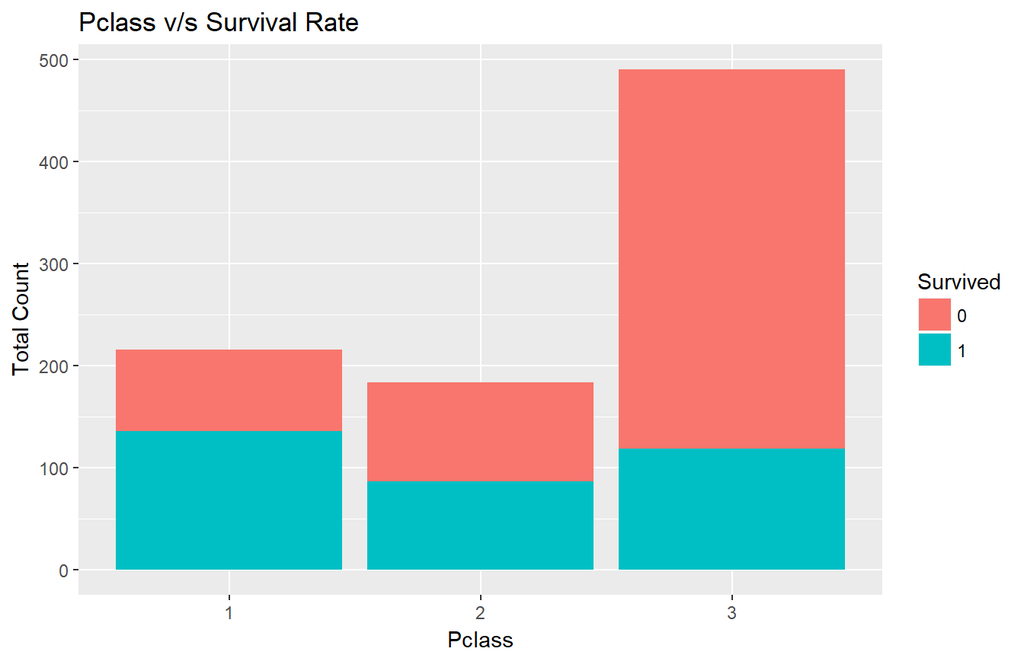

```r
ggplot(dataset,aes(x=Pclass,fill=factor(Survived))) +
geom_bar()+
ggtitle("Pclass v/s Survival Rate")+
xlab("Pclass") +
ylab("Total Count") +
labs(fill = "Survived")
```

No diffrence in the Titanic too, First class Survival rate is far better than the third class.

## 3.2 Exploratory Analysis on Gender: Are Female more likely to survive?

Hypothesis, **gender** and survival rate are related.

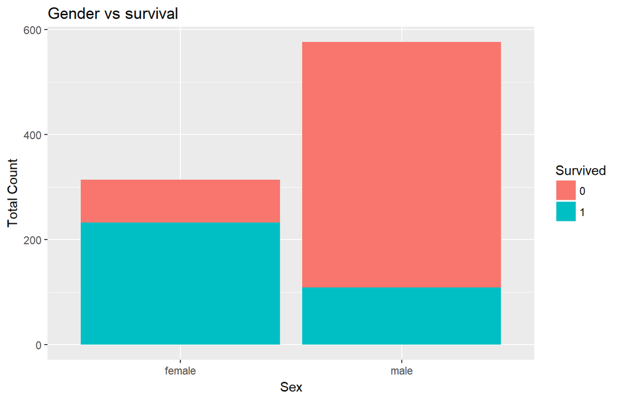

```r
ggplot(dataset, aes(x = Sex, fill = Survived)) +
geom_bar() +
ggtitle("Gender vs survival") +
xlab("Sex") +
ylab("Total Count") +
labs(fill = "Survived")
```

Female survival rate is much higher than Male.

Visualize the 3-way relationship of sex, pclass, and survival

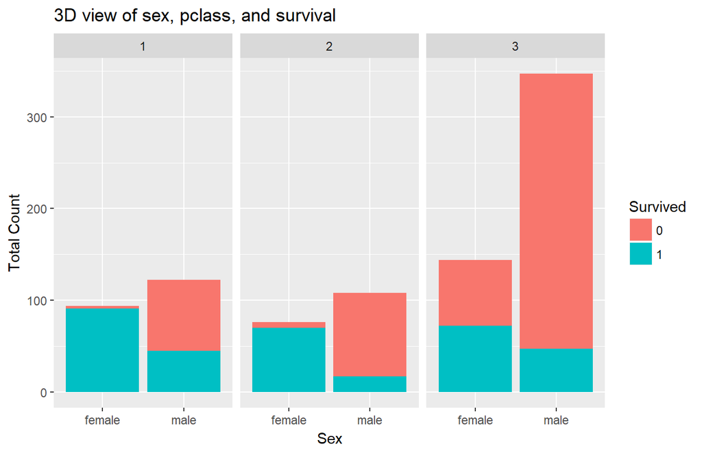

```r
ggplot(dataset, aes(x = Sex, fill = Survived)) +
geom_bar() +
facet_wrap(~Pclass) +
ggtitle("3D view of sex, pclass, and survival") +
xlab("Sex") +
ylab("Total Count") +
labs(fill = "Survived")
```

## 3.3 Exploratory Analysis on Name

```r
head(dataset$Name)
```

```
## [1] "Braund, Mr. Owen Harris"
## [2] "Cumings, Mrs. John Bradley (Florence Briggs Thayer)"
## [3] "Heikkinen, Miss. Laina"
## [4] "Futrelle, Mrs. Jacques Heath (Lily May Peel)"
## [5] "Allen, Mr. William Henry"
## [6] "Moran, Mr. James"
```

Lets extract the title and check if we have predictive power in that -

```r
# Grab title from passenger names
names <- dataset$Name
title <-  gsub("^.*, (.*?)\\..*$", "\\1", names)
dataset$Title <- title

# Show title counts by sex
table(dataset$Sex, dataset$Title)
```

```
##
##          Capt Col Don  Dr Jonkheer Lady Major Master Miss Mlle Mme  Mr Mrs
##   female    0   0   0   1        0    1     0      0  182    2   1   0 125
##   male      1   2   1   6        1    0     2     40    0    0   0 517   0
##
##           Ms Rev Sir the Countess
##   female   1   0   0            1
##   male     0   6   1            0
```

Miss, Mrs, Master and Mr are taking more numbers. Creating a new varible with small data can cause overfitting. Better to group Other titles into bigger basket by checking gender and survival rate to avoid any overfitting.

```r
# Army folks, doctors and nobel people to be combined in one group - "Officer" level
officer <- c('Capt', 'Col', 'Don', 'Dr', 'Major', 'Rev', 'Sir', 'Jonkheer', 'the Countess')
dataset$Title[dataset$Title %in% officer]  <- 'Officer'

# Also reassign mlle, ms, and mme accordingly
dataset$Title[dataset$Title == 'Mlle']        <- 'Miss'
dataset$Title[dataset$Title == 'Ms']          <- 'Miss'
dataset$Title[dataset$Title == 'Lady']         <- 'Miss'
dataset$Title[dataset$Title == 'Dona']         <- 'Miss'
dataset$Title[dataset$Title == 'Mme']         <- 'Mrs'

# Show title counts by sex again
table(dataset$Sex, dataset$Title)
```

```
##
##          Master Miss  Mr Mrs Officer
##   female      0  186   0 126       2
##   male       40    0 517   0      20
```

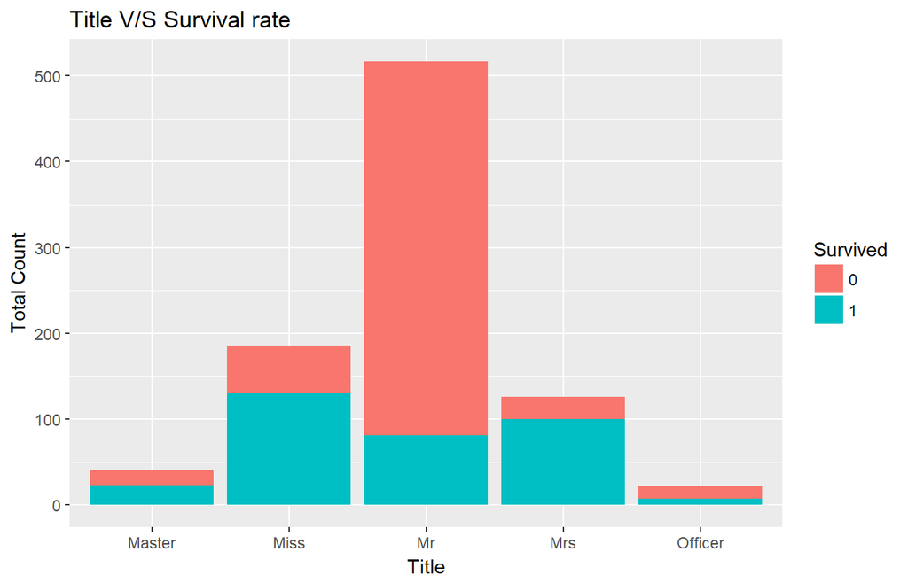

```r
# Lets check Title vs survival rate
ggplot(dataset,aes(x = Title,fill=factor(Survived))) +
geom_bar() +
ggtitle("Title V/S Survival rate")+
xlab("Title") +
ylab("Total Count") +
labs(fill = "Survived")
```

So in the titanic, if you are a Mr then there is less chance of survival, Miss and Mrs have better survival rate than Master and Officer.

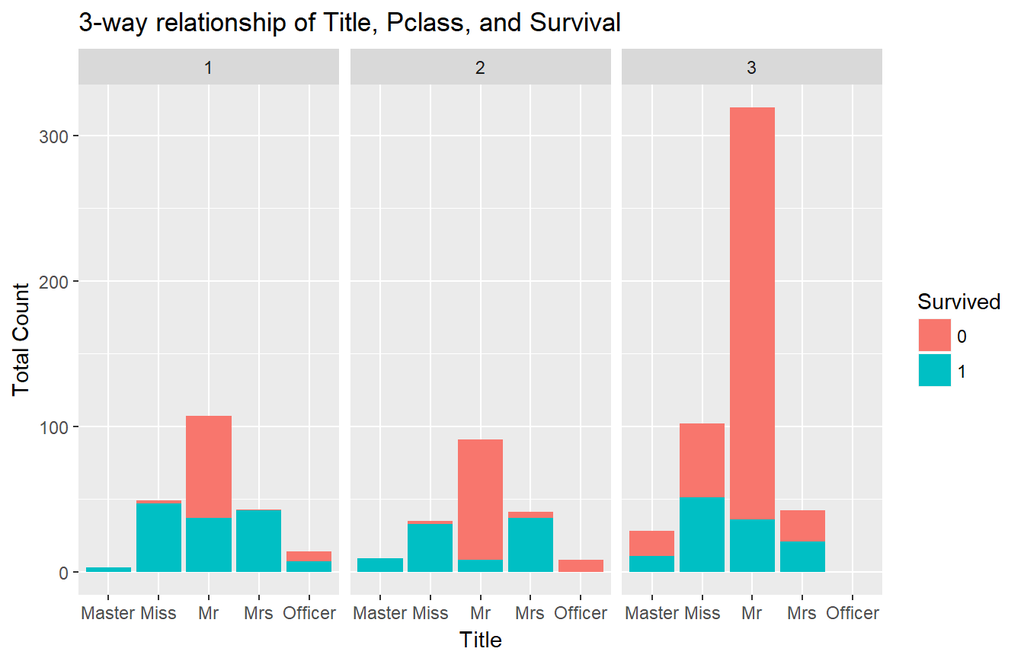

```r
# Visualize the 3-way relationship of Title, Pclass, and Survival

ggplot(dataset, aes(x = Title, fill = Survived)) +
  geom_bar() +
  facet_wrap(~Pclass) +
  ggtitle("3-way relationship of Title, Pclass, and Survival") +
  xlab("Title") +
  ylab("Total Count") +
  labs(fill = "Survived")
```

Since Title is mostly dependent on the Age (except few cases), I will use title as a proxy for age.

## 3.4 Exploratory Analysis on Family : Do families sink or swim together?

First we’re going to make a family size variable based on number of siblings/spouse(s) (maybe someone has more than one spouse?) and number of children/parents.

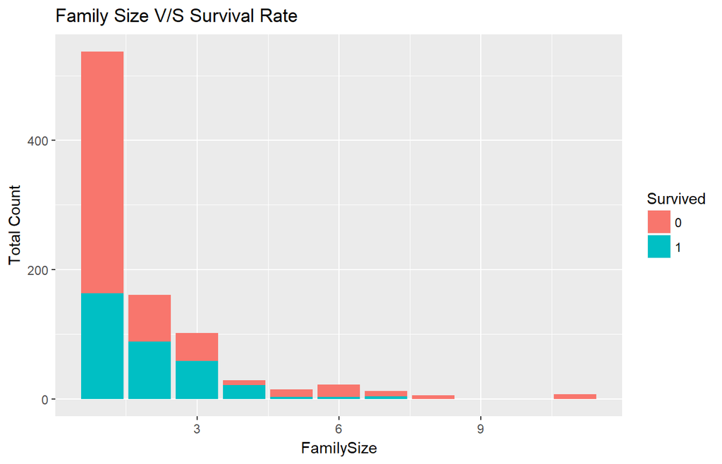

```r
# Create a family size variable including the passenger themselves
dataset$Fsize <- dataset$SibSp + dataset$Parch + 1

# Use ggplot2 to visualize the relationship between family size & survival
ggplot(dataset, aes(x = Fsize, fill = Survived)) +
  geom_bar() +
  ggtitle("Family Size V/S Survival Rate") +
  xlab("FamilySize") +
  ylab("Total Count") +
  labs(fill = "Survived")
```

We can see that there’s a survival penalty to singletons and those with family sizes above 4. We can collapse this variable into three levels which will be helpful since there are comparatively fewer large families. Let’s create a discretized family size variable.

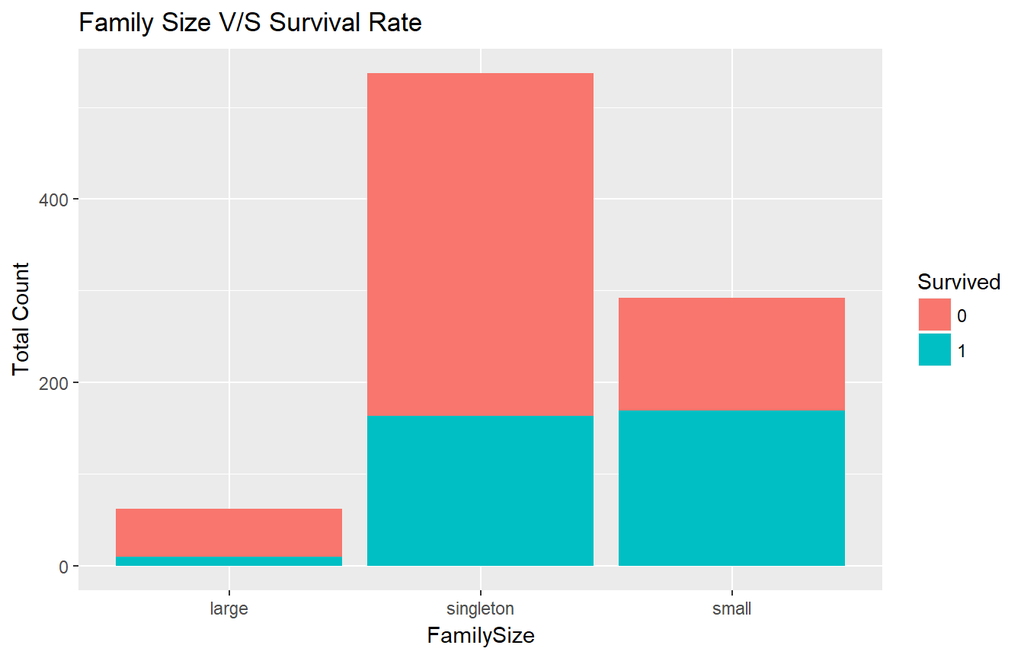

```r
# Discretize family size
dataset$FsizeD[dataset$Fsize == 1] <- 'singleton'
dataset$FsizeD[dataset$Fsize < 5 & dataset$Fsize > 1] <- 'small'
dataset$FsizeD[dataset$Fsize > 4] <- 'large'

ggplot(dataset, aes(x = FsizeD, fill = Survived)) +
  geom_bar() +
  ggtitle("Family Size V/S Survival Rate") +
  xlab("FamilySize") +
  ylab("Total Count") +
  labs(fill = "Survived")
```

The plot shows that there is a survival penalty among singletons and large families.

## 3.5 Exploratory Analysis on Embarked

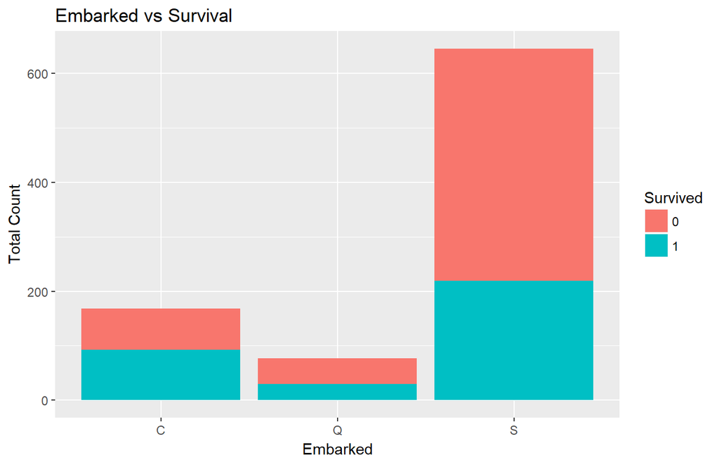

```r
###is there any association between Survial rate and where we get into the Ship.
ggplot(dataset,aes(x = Embarked,fill=factor(Survived))) +
geom_bar() +
ggtitle("Embarked vs Survival") +
xlab("Embarked") +
ylab("Total Count") +
labs(fill = "Survived")
```

# 4 Prediction

## 4.1 Split into training & test sets

- Divide data into train and test set for internal validation

```r
# Set a random seed
set.seed(123)

split = sample.split(dataset$Survived, SplitRatio = 0.80)

training_set = subset(dataset, split == TRUE)
test_set = subset(dataset, split == FALSE)

# Structure of the data
str(training_set)
```

```
## 'data.frame':    713 obs. of  15 variables:
##  $ PassengerId: int  1 2 3 4 5 6 9 11 12 13 ...
##  $ Survived   : Factor w/ 2 levels "0","1": 1 2 2 2 1 1 2 2 2 1 ...
##  $ Pclass     : Factor w/ 3 levels "1","2","3": 3 1 3 1 3 3 3 3 1 3 ...
##  $ Name       : chr  "Braund, Mr. Owen Harris" "Cumings, Mrs. John Bradley (Florence Briggs Thayer)" "Heikkinen, Miss. Laina" "Futrelle, Mrs. Jacques Heath (Lily May Peel)" ...
##  $ Sex        : Factor w/ 2 levels "female","male": 2 1 1 1 2 2 1 1 1 2 ...
##  $ Age        : num  22 38 26 35 35 NA 27 4 58 20 ...
##  $ SibSp      : int  1 1 0 1 0 0 0 1 0 0 ...
##  $ Parch      : int  0 0 0 0 0 0 2 1 0 0 ...
##  $ Ticket     : chr  "A/5 21171" "PC 17599" "STON/O2. 3101282" "113803" ...
##  $ Fare       : num  7.25 71.28 7.92 53.1 8.05 ...
##  $ Cabin      : chr  NA "C85" NA "C123" ...
##  $ Embarked   : Factor w/ 3 levels "C","Q","S": 3 1 3 3 3 2 3 3 3 3 ...
##  $ Title      : chr  "Mr" "Mrs" "Miss" "Mrs" ...
##  $ Fsize      : num  2 2 1 2 1 1 3 3 1 1 ...
##  $ FsizeD     : chr  "small" "small" "singleton" "small" ...
```

## 4.2 Building the model

We then build our model using logistic regression on the training set.

```r
# Build the model (note: not all possible variables are used)
LogReg_model <- glm(factor(Survived) ~ Pclass + Sex + SibSp + Parch + Fare + Embarked +                       Title + FsizeD, data = training_set, family = binomial)

summary(LogReg_model)
```

```
##
## Call:
## glm(formula = factor(Survived) ~ Pclass + Sex + SibSp + Parch +
##     Fare + Embarked + Title + FsizeD, family = binomial, data = training_set)
##
## Deviance Residuals:
##     Min       1Q   Median       3Q      Max
## -2.4304  -0.5803  -0.4057   0.5843   2.3501
##
## Coefficients:
##                   Estimate Std. Error z value Pr(>|z|)
## (Intercept)      16.223370 623.720084   0.026  0.97925
## Pclass2          -0.883198   0.345460  -2.557  0.01057 *
## Pclass3          -1.688510   0.331370  -5.096 3.48e-07 ***
## Sexmale         -15.339578 623.718685  -0.025  0.98038
## SibSp            -0.079738   0.216183  -0.369  0.71224
## Parch             0.128048   0.228826   0.560  0.57576
## Fare              0.002306   0.002861   0.806  0.42027
## EmbarkedQ        -0.015765   0.464500  -0.034  0.97292
## EmbarkedS        -0.466346   0.286509  -1.628  0.10359
## TitleMiss       -16.057391 623.718947  -0.026  0.97946
## TitleMr          -3.808778   0.614254  -6.201 5.62e-10 ***
## TitleMrs        -15.828351 623.718978  -0.025  0.97975
## TitleOfficer     -3.925463   0.854629  -4.593 4.37e-06 ***
## FsizeDsingleton   2.605782   1.162785   2.241  0.02503 *
## FsizeDsmall       2.445383   0.891141   2.744  0.00607 **
## ---
## Signif. codes:  0 '***' 0.001 '**' 0.01 '*' 0.05 '.' 0.1 ' ' 1
##
## (Dispersion parameter for binomial family taken to be 1)
##
##     Null deviance: 949.90  on 712  degrees of freedom
## Residual deviance: 584.77  on 698  degrees of freedom
## AIC: 614.77
##
## Number of Fisher Scoring iterations: 13
```

```r
# Backward Elimination to choose the predictors - Iternation 2 - Sex removed
LogReg_model <- glm(factor(Survived) ~ Pclass + SibSp + Parch + Fare + Embarked + Title + FsizeD,
                    data = training_set, family = binomial)

summary(LogReg_model)
```

```
##
## Call:
## glm(formula = factor(Survived) ~ Pclass + SibSp + Parch + Fare +
##     Embarked + Title + FsizeD, family = binomial, data = training_set)
##
## Deviance Residuals:
##     Min       1Q   Median       3Q      Max
## -2.4499  -0.5896  -0.4080   0.5851   2.3563
##
## Coefficients:
##                  Estimate Std. Error z value Pr(>|z|)
## (Intercept)      0.873186   1.316405   0.663  0.50713
## Pclass2         -0.932903   0.342997  -2.720  0.00653 **
## Pclass3         -1.709176   0.330288  -5.175 2.28e-07 ***
## SibSp           -0.082376   0.216385  -0.381  0.70343
## Parch            0.133150   0.228844   0.582  0.56068
## Fare             0.002409   0.002863   0.841  0.40022
## EmbarkedQ       -0.013142   0.464128  -0.028  0.97741
## EmbarkedS       -0.429947   0.285956  -1.504  0.13270
## TitleMiss       -0.739367   0.603277  -1.226  0.22035
## TitleMr         -3.840898   0.615237  -6.243 4.29e-10 ***
## TitleMrs        -0.500930   0.622879  -0.804  0.42127
## TitleOfficer    -3.568559   0.806079  -4.427 9.55e-06 ***
## FsizeDsingleton  2.643621   1.163771   2.272  0.02311 *
## FsizeDsmall      2.458772   0.892022   2.756  0.00584 **
## ---
## Signif. codes:  0 '***' 0.001 '**' 0.01 '*' 0.05 '.' 0.1 ' ' 1
##
## (Dispersion parameter for binomial family taken to be 1)
##
##     Null deviance: 949.90  on 712  degrees of freedom
## Residual deviance: 588.78  on 699  degrees of freedom
## AIC: 616.78
##
## Number of Fisher Scoring iterations: 5
```

```r
# Iteration 3 - Embarked Removed
LogReg_model <- glm(factor(Survived) ~ Pclass + SibSp + Parch + Fare + Title + FsizeD,
                                      data = training_set, family = binomial)

summary(LogReg_model)
```

```
##
## Call:
## glm(formula = factor(Survived) ~ Pclass + SibSp + Parch + Fare +
##     Title + FsizeD, family = binomial, data = training_set)
##
## Deviance Residuals:
##     Min       1Q   Median       3Q      Max
## -2.5263  -0.5943  -0.4316   0.5857   2.3299
##
## Coefficients:
##                  Estimate Std. Error z value Pr(>|z|)
## (Intercept)      0.578736   1.295496   0.447  0.65507
## Pclass2         -1.024936   0.337548  -3.036  0.00239 **
## Pclass3         -1.698222   0.323387  -5.251 1.51e-07 ***
## SibSp           -0.105340   0.216363  -0.487  0.62635
## Parch            0.121883   0.226943   0.537  0.59122
## Fare             0.003167   0.002825   1.121  0.26218
## TitleMiss       -0.760166   0.607624  -1.251  0.21092
## TitleMr         -3.927228   0.619170  -6.343 2.26e-10 ***
## TitleMrs        -0.586280   0.626993  -0.935  0.34975
## TitleOfficer    -3.618894   0.808865  -4.474 7.68e-06 ***
## FsizeDsingleton  2.696037   1.160850   2.322  0.02021 *
## FsizeDsmall      2.538171   0.888376   2.857  0.00428 **
## ---
## Signif. codes:  0 '***' 0.001 '**' 0.01 '*' 0.05 '.' 0.1 ' ' 1
##
## (Dispersion parameter for binomial family taken to be 1)
##
##     Null deviance: 949.90  on 712  degrees of freedom
## Residual deviance: 591.77  on 701  degrees of freedom
## AIC: 615.77
##
## Number of Fisher Scoring iterations: 5
```

```r
# Iteration 4 - SibSp removed
LogReg_model <- glm(factor(Survived) ~ Pclass + Parch + Fare + Title + FsizeD,
                                      data = training_set, family = binomial)

summary(LogReg_model)
```

```
##
## Call:
## glm(formula = factor(Survived) ~ Pclass + Parch + Fare + Title +
##     FsizeD, family = binomial, data = training_set)
##
## Deviance Residuals:
##     Min       1Q   Median       3Q      Max
## -2.5712  -0.5929  -0.4310   0.5907   2.3193
##
## Coefficients:
##                  Estimate Std. Error z value Pr(>|z|)
## (Intercept)      0.063439   0.764694   0.083  0.93388
## Pclass2         -1.040973   0.336192  -3.096  0.00196 **
## Pclass3         -1.711670   0.322309  -5.311 1.09e-07 ***
## Parch            0.181084   0.193199   0.937  0.34861
## Fare             0.003169   0.002826   1.121  0.26209
## TitleMiss       -0.702233   0.588066  -1.194  0.23242
## TitleMr         -3.866751   0.599606  -6.449 1.13e-10 ***
## TitleMrs        -0.508905   0.601450  -0.846  0.39748
## TitleOfficer    -3.569663   0.798277  -4.472 7.76e-06 ***
## FsizeDsingleton  3.161702   0.684609   4.618 3.87e-06 ***
## FsizeDsmall      2.871165   0.586223   4.898 9.69e-07 ***
## ---
## Signif. codes:  0 '***' 0.001 '**' 0.01 '*' 0.05 '.' 0.1 ' ' 1
##
## (Dispersion parameter for binomial family taken to be 1)
##
##     Null deviance: 949.90  on 712  degrees of freedom
## Residual deviance: 592.02  on 702  degrees of freedom
## AIC: 614.02
##
## Number of Fisher Scoring iterations: 5
```

```r
# Iteration 5 - Parch removed
LogReg_model <- glm(factor(Survived) ~ Pclass + Fare + Title + FsizeD,
                                      data = training_set, family = binomial)

summary(LogReg_model)
```

```
##
## Call:
## glm(formula = factor(Survived) ~ Pclass + Fare + Title + FsizeD,
##     family = binomial, data = training_set)
##
## Deviance Residuals:
##     Min       1Q   Median       3Q      Max
## -2.4947  -0.5950  -0.4304   0.5965   2.2744
##
## Coefficients:
##                  Estimate Std. Error z value Pr(>|z|)
## (Intercept)      0.417732   0.652749   0.640   0.5222
## Pclass2         -1.012381   0.334812  -3.024   0.0025 **
## Pclass3         -1.692072   0.322041  -5.254 1.49e-07 ***
## Fare             0.003327   0.002839   1.172   0.2413
## TitleMiss       -0.661662   0.572026  -1.157   0.2474
## TitleMr         -3.835131   0.585458  -6.551 5.73e-11 ***
## TitleMrs        -0.431301   0.587035  -0.735   0.4625
## TitleOfficer    -3.547560   0.788106  -4.501 6.75e-06 ***
## FsizeDsingleton  2.752973   0.513646   5.360 8.34e-08 ***
## FsizeDsmall      2.575550   0.484595   5.315 1.07e-07 ***
## ---
## Signif. codes:  0 '***' 0.001 '**' 0.01 '*' 0.05 '.' 0.1 ' ' 1
##
## (Dispersion parameter for binomial family taken to be 1)
##
##     Null deviance: 949.90  on 712  degrees of freedom
## Residual deviance: 592.89  on 703  degrees of freedom
## AIC: 612.89
##
## Number of Fisher Scoring iterations: 5
```

```r
# Iteration 6 - Fare removed
LogReg_model <- glm(factor(Survived) ~ Pclass + Title + FsizeD,
                                      data = training_set, family = binomial)

summary(LogReg_model)
```

```
##
## Call:
## glm(formula = factor(Survived) ~ Pclass + Title + FsizeD, family = binomial,
##     data = training_set)
##
## Deviance Residuals:
##     Min       1Q   Median       3Q      Max
## -2.4009  -0.5974  -0.4262   0.5957   2.2549
##
## Coefficients:
##                 Estimate Std. Error z value Pr(>|z|)
## (Intercept)       0.7863     0.5681   1.384    0.166
## Pclass2          -1.1851     0.3012  -3.934 8.35e-05 ***
## Pclass3          -1.9051     0.2670  -7.135 9.66e-13 ***
## TitleMiss        -0.5759     0.5593  -1.030    0.303
## TitleMr          -3.7740     0.5755  -6.558 5.47e-11 ***
## TitleMrs         -0.3945     0.5787  -0.682    0.496
## TitleOfficer     -3.5308     0.7830  -4.509 6.51e-06 ***
## FsizeDsingleton   2.5399     0.4686   5.420 5.96e-08 ***
## FsizeDsmall       2.4326     0.4588   5.302 1.15e-07 ***
## ---
## Signif. codes:  0 '***' 0.001 '**' 0.01 '*' 0.05 '.' 0.1 ' ' 1
##
## (Dispersion parameter for binomial family taken to be 1)
##
##     Null deviance: 949.90  on 712  degrees of freedom
## Residual deviance: 594.35  on 704  degrees of freedom
## AIC: 612.35
##
## Number of Fisher Scoring iterations: 5
```

Final Set of Variable: **Pclass**,**Title**,**FsizeD**

Find set of variables using backward variable selection:

```r
attach(training_set)
# Fast backward Selection
fullmodel <- fastbw(lrm(factor(Survived) ~ Pclass + Sex + SibSp + Parch + Fare + Embarked + Title + FsizeD)                     ,rule="p")
fullmodel
```

```
##
##  Deleted  Chi-Sq d.f. P      Residual d.f. P      AIC
##  Sex      0.09   1    0.7675 0.09     1    0.7675 -1.91
##  SibSp    0.14   1    0.7121 0.22     2    0.8942 -3.78
##  Fare     0.64   1    0.4231 0.87     3    0.8338 -5.13
##  Parch    0.86   1    0.3542 1.72     4    0.7864 -6.28
##  Embarked 4.24   2    0.1202 5.96     6    0.4276 -6.04
##
## Approximate Estimates after Deleting Factors
##
##                     Coef   S.E.  Wald Z         P
## Intercept         0.7598 0.5835  1.3021 1.929e-01
## Pclass=2         -1.1366 0.3034 -3.7461 1.796e-04
## Pclass=3         -1.8696 0.2696 -6.9349 4.064e-12
## Title=Miss       -0.5468 0.5821 -0.9393 3.476e-01
## Title=Mr         -3.7098 0.5946 -6.2389 4.407e-10
## Title=Mrs        -0.3850 0.5917 -0.6506 5.153e-01
## Title=Officer    -3.8209 0.8477 -4.5072 6.570e-06
## FsizeD=singleton  2.4827 0.4815  5.1557 2.527e-07
## FsizeD=small      2.4006 0.4685  5.1242 2.989e-07
##
## Factors in Final Model
##
## [1] Pclass Title  FsizeD
```

```r
# Predicting the Test set results
prob_pred = predict(LogReg_model, type = 'response', newdata = test_set[c("Pclass","Title","FsizeD")])
Survived_pred = ifelse(prob_pred > 0.5, 1, 0)

# Making the Confusion Matrix
cm = table(test_set$Survived, Survived_pred)
cm
```

```
##    Survived_pred
##      0  1
##   0 96 14
##   1 17 51
```

```r
# Accuracy
Accuracy = (96+51)/length(test_set$Survived)
Accuracy
```

```
## [1] 0.8258427
```